# Species distribution

Steven Unger

1/31/2020

# Methods

## Species Information

The Saguaro cactus (*Carnegiea gigantea*) is a columnar cactus endemic to the Sonoran Desert (western Sonora Desert and southern Arizona). It is considered a keystone species because of how many species rely on all the different life stages of the plant for food, nesting, shade, etc (Drezner, 2014). There is increasing fears of population collapse because of invasive grass species which are encouraging a fire regime which Saguaro cacti did not evolve to experience. As the climate warms, and grasses invade, saguaro cacti populations are expected to decline (Hauser, 1993),(Marshall *et al*, 2012),(Schiermeier, 2005). Thus, it is critically important to understand the species distribution to inform and direct conservation and restoration efforts.

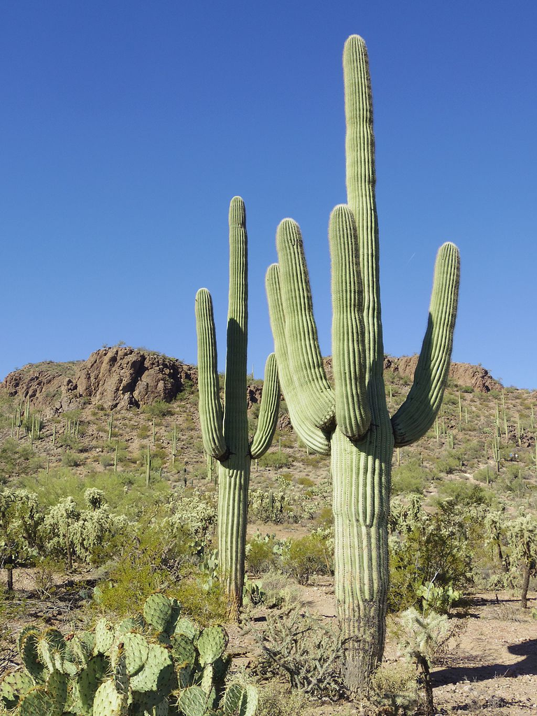

Saguaro Cacrtus (*Carnegiea gigantea*)

## Statistical Analysis

BIOCLIM is an algorithm is a very useful modeling method used for species distribution, especially to teach newcomers. Despite newer models performing better than BIOCLIM, the simplicity and ease of use allow students to hone their skills and grasp otherwise complex modelling. The algorith relies on constraining the similarity of locations to the mean if they are near either tail of the distribution. A transformation is performed by using the value obtained via using the minimum tail, subtracting by 1 and multiplying by 2 to ensure a value between 0 and 1. This is done to enable easier analysis interpretation.

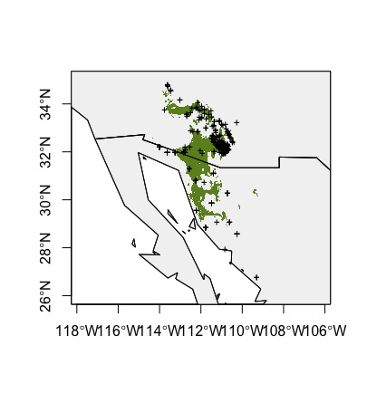

Figure 1: Saguaro distribution

**Dependent species**

| Common.name | Use |
| --- | --- |
| Gila woodpeckers | Nests |
| House Finches | Nests |
| Gilded Flickers | Nests |
| Purple Martins | Nests |
| Elf owls | Secondary nests |
| Tyrant Flycatchers | Secondary nests |
| Wrens | Secondary nests |
| White-wing dove | Eat fruits |
| Ants | Eat fruits |
| Honey bee | Eats nectar |
| Flies | Eats decomposing tissue |
| Beetles | Eats decomposing tissue |
| Desert Iguana | eats flowers |
| Sonora harvest mouse | eats seedlings |
| Desert kangaroo rat | eats flowers and seedlings |
| Gray Fox | eats fruit |
| Jack rabbit | fruit |
| Vulture | Roosting perch |
| Humans | eat fruit and seeds, water vessel , use as feed |

Table 1: List of some common species which depend on Saguaro cacti and what it is that they use them for. Not an exhuastive list. Information pulled from (Drezner, 2014), except human uses.

# **Discussion**

A model showing the distribution of Saguaro cactus (*Carnegiea gigantea*) was created in R studio by using occurance data (GPS points of where the species has been recorded) and environmental data (19 abiotic factors). The model used occurance points as well as pseudo-absence points coupled with BIOCLIM data which factored 19 abiotic variables including various temperature and precipitation parameters (max, min, mean, etc) into the model to not only map the occurance, but also predict where other individuals are likely to exist. This mapping distribution could be very useful to managment officials and researchers who continue to monitor the effects of invasives, as well as monitoring the health of the Sonoran desert by using the keystone species Saguaro cactus as a proxy. While various methods have been developed to more accurately map species distribution, this method is a great starting point to teach young scientist how to code and analysis species distributions.

### Works Cited

Drezner, Taly Dawn (2014-06-01). “The keystone saguaro (Carnegiea gigantea, Cactaceae): a review of its ecology, associations, reproduction, limits, and demographics”. Plant Ecology. 215 (6): 581–595.

Hauser, A. Scott (1993). “Pennisetum ciliare”. US Forest Service Fire Effects Information System. U.S. Department of Agriculture, US Forest Service, Rocky Mountain Research Station, Fire Sciences Laboratory (Producer).

Marshall, V. M.; Lewis, M. M.; Ostendorf, B. (2012-03-01). “Buffel grass (Cenchrus ciliaris) as an invader and threat to biodiversity in arid environments: A review”. Journal of Arid Environments. 78: 1–12.

Schiermeier, Quirin (2005-06-01). “Pall hangs over desert’s future as alien weeds fuel wildfires”. Nature. 435 (7043): 724.